# data

```python
#import libraries

import pandas as pd
import numpy as np
import warnings
warnings.filterwarnings(action='ignore')

from sklearn.metrics import f1_score,accuracy_score,recall_score,precision_score,roc_curve, auc, plot_confusion_matrix, precision_recall_fscore_support, precision_recall_curve,confusion_matrix
from sklearn.metrics import classification_report
import plotly.express as px


from xgboost import XGBClassifier, plot_importance
from sklearn.model_selection import StratifiedKFold, cross_val_score
from sklearn.ensemble import RandomForestClassifier, VotingClassifier, StackingClassifier
from sklearn.feature_selection import RFE

import matplotlib.pyplot as plt
%matplotlib inline

import seaborn as sns
from datetime import datetime
from matplotlib import pyplot


import matplotlib.font_manager as fm
path = '/home/AAA/Font/NanumGothic.ttf'
fontprop = fm.FontProperties(fname=path, size=18)
fe = fm.FontEntry(fname='../Font/NanumGothic.ttf', name='NanumGothic')
fm.fontManager.ttflist.insert(0, fe) # or append is fine
plt.rcParams['font.family'] = fe.name # = 'your custom ttf font name'
# sns.set_theme(font ='NanumGothic', rc = {'axes.unicode_minus' : False}, style ='darkgrid')
plt.rc("font", family = "NanumGothic")
sns.set(font="NanumGothic",
rc={"axes.unicode_minus":False}, style='darkgrid')


pd.set_option('display.max_columns', 100) #pd 컬럼 결과 모두 출력
pd.set_option('display.max_rows', 500) #pd 행 결과 모두 출력
np.set_printoptions(threshold=np.inf) # 배열의 모두를 출력


# data 불러오기
raw_data = pd.read_csv('data_final.csv',encoding='cp949',index_col=0)
raw_df = raw_data.copy()
raw_df.info()


# 연속형 변수
data_num = raw_df.select_dtypes(exclude = object)

#범주형 변수
data_obj = raw_df.select_dtypes(include = object)
data_unique = pd.DataFrame({'col' : data_obj.columns})
list_unique = []

for i in range(len(data_obj.columns)):
    list_unique.append(data_obj.iloc[:, i].unique().tolist())
data_unique['unique'] = list_unique
```

```
<class 'pandas.core.frame.DataFrame'>
Int64Index: 1749907 entries, 0 to 1749906
Data columns (total 35 columns):
 #   Column        Dtype
---  ------        -----
 0   서비스이용일그룹      object
 1   미디어그룹명        object
 2   상품명그룹         object
 3   구상품여부         object
 4   약정종류          object
 5   셋톱1개월이용안함     object
 6   SVOD가입건수      object
 7   유료채널가입그룹      object
 8   가입경로명         object
 9   약정종료          object
```

[output cut: 27 more lines]

# Preprocessing

```python
# 전처리

# null값 처리
# 결측치율 매우 낮음. 데이터 삭제해도 무방하다고 생각.
print('결측치비율: ',len(raw_df.dropna())/len(raw_df))
raw_df.dropna(inplace=True)
# null값 제거 확인
print('결측치여부:',raw_df.isnull().sum().any())
print(raw_df.해지여부.unique())

#컬럼삭제
print('_____________________________________________')
print('\n')

# EDA를 통해 아래 컬럼의 데이터가 정보없음 혹은 오류가 있다고 간주하여 삭제
raw_df = raw_df.drop(columns=['키즈컨텐츠이용여부','SMS수신분류명','이메일수신분류명','TV인터넷가입건수','디지털기가가입여부','기가인터넷가입건수','디지털가입','아날로그가입','약정종료년월','구상품여부','1달이용금액','3달이용금액','넷플릭시이용여부','유튜브이용여부'],axis=1)
print('EDA를 통해 총 14개의 컬럼의 데이터가 정보없음 혹은 의미가 없다고 간주하여 삭제')
print('\n')

# 연속형 변수 >>>>>>> 범주화진행
#렌탈제휴 10건 --> 기타
raw_df['가입경로명'] = np.where(raw_df['가입경로명'] == '렌탈제휴', '기타', raw_df['가입경로명'])

#[총이용일수] 3년 단위로 구간화
bins = [0,1095, 2190, 3285, 4380, 5475,10000000000]
labels = ['3년 미만', '3년이상 6년미만', '6년이상 9년미만', '9년이상 12년미만', '12년이상 15년미만','15년이상']
raw_df['총이용일수'] = pd.cut(raw_df['총이용일수'], bins, right=False, labels=labels)

#[TV가입],[총인터넷가입] 재범주화
raw_df['TV가입'] = np.where(raw_df['TV가입'] == 1, '1건', np.where(raw_df['TV가입'] == 2, '2건', '3건 이상'))
raw_df['총인터넷가입'] = np.where(raw_df['총인터넷가입'] == 0, '0건', np.where(raw_df['총인터넷가입'] == 1, '1건', '2건 이상'))

#[선호채널] 범주화 안함

#[1개월평균채널시청시간] 범주화
bins = [0,0.001, 2.767, 5.33, 8.66, 10000000000]
labels = ['0', '1Q', '2Q', '3Q', '4Q']
raw_df['1개월평균채널시청시간'] = pd.cut(raw_df['1개월평균채널시청시간'], bins, right=False, labels=labels)

#키즈콘텐츠PV
raw_df['키즈컨텐츠PV'] = np.where(raw_df['키즈컨텐츠PV'] == 0, '0건', '1건 이상')

#키즈콘텐츠VOD이용여부
raw_df['키즈컨텐츠VOD이용여부'] = np.where(raw_df['키즈컨텐츠VOD이용여부'] == 0, '0건', '1건 이상')

print('_____________________________________________')
print('\n')
print('연속형 변수 범주화 완료')
```

```
결측치비율:  0.9999954283284769
결측치여부: False
[0 1]
_____________________________________________


EDA를 통해 총 14개의 컬럼의 데이터가 정보없음 혹은 의미가 없다고 간주하여 삭제


_____________________________________________


연속형 변수 범주화 완료
```

# Encoding

```python
# 인코딩

print('범주형 데이터 원핫인코딩 진행 , 공선성 이유로 drop_first=True 처리')
print('_____________________________________________')
print('\n')

# 범주형 데이터 원핫인코딩 진행 , 공선성 이유로 drop_first=True 처리
df = pd.get_dummies(raw_df ,drop_first=True)
print('df shape: ',df.shape)
print('\n')
# 종속변수, 독립변수 설정
X = df.drop(columns='해지여부',axis=1)
y= df.해지여부
print('_____________________________________________')
print('\n')
print('종속변수, 독립변수 설정 완료: X,y')
```

```
범주형 데이터 원핫인코딩 진행 , 공선성 이유로 drop_first=True 처리
_____________________________________________


df shape:  (1749899, 75)


_____________________________________________


종속변수, 독립변수 설정 완료: X,y
```

# Data Split

```python
# 6:2:2 비율로 data split


from sklearn.model_selection import train_test_split
X_train, X_test, y_train, y_test = train_test_split(X, y, test_size = 0.2, stratify=y, random_state=2357)
X_train, X_val, y_train, y_val = train_test_split(X_train, y_train, test_size = 0.25, stratify=y_train, random_state=2357)
print('_____________________________Data Split completed__________________________')
```

```
_____________________________Data Split completed__________________________
```

# Sampling

```python
# 1:1 비율로 랜덤언더샘플링
from imblearn.under_sampling import RandomUnderSampler
from collections import Counter

undersample = RandomUnderSampler(random_state=2357)
X_train, y_train = undersample.fit_resample(X_train, y_train)
print(len(X_train))
print(Counter(y_train))
```

```
14100
Counter({0: 7050, 1: 7050})
```

# Scaling

```python
# StandardScaling

X_train = X_train.reset_index(drop=True)
X_test = X_test.reset_index(drop=True)

# standardscaler
from sklearn.preprocessing import StandardScaler
import pandas as pd

# 객체생성
scaler = StandardScaler()

# fit -> transform
scaler.fit(X_train.iloc[:,:10]) # df는 2차원 이상의 값이어야 함
df_scaled = scaler.transform(X_train.iloc[:,:10])
# 배열형태로 반환되기 때문에 데이터 프레임으로 변환해주는 작업
X_train_scaled = pd.DataFrame(data = df_scaled)

# train분포로 test dataset transform만 진행
df_scaled_test = scaler.transform(X_test.iloc[:,:10])
X_test_scaled = pd.DataFrame(data = df_scaled_test)

#df컬럼명설정
dum_cols =X_test.iloc[:,:10].columns.to_list()
X_train_scaled.columns = dum_cols
X_test_scaled.columns = dum_cols

X_train = pd.concat([X_train_scaled,X_train.iloc[:,10:]],axis=1)
X_test = pd.concat([X_test_scaled,X_test.iloc[:,10:]],axis=1)

print(X_train.shape, X_test.shape)
```

```
(14100, 74) (349980, 74)
```

# LOGISTIC

```python
# logistic 모델
def logistic(X_train,y_train,X_test,y_test):


    # 모델
    global logist, coef

    from sklearn.linear_model import LogisticRegression
    logist = LogisticRegression()  #penalty='l1', solver='liblinear'
    logist.fit(X_train, y_train)
    coef = logist.coef_.reshape(-1)

    #score and prediction
    global y_train_proba, y_train_pred,y_proba,y_pred

    # train data set
    y_train_proba= logist.predict_proba(X_train)[:, 1]
    y_train_pred = logist.predict(X_train)

    # test data set
    y_proba = logist.predict_proba(X_test)[:, 1]
    y_pred = logist.predict(X_test)

    print('___________________________________________________________________Logistic_______________________________________________________________________________')


    print('----------------------------------------------------------------feature_weights-------------------------------------------------------------------------')
    print('\n')

    #feature_weights
    global df_features

    df_features = pd.DataFrame(columns=['col','weight'])
    for idx, w in sorted(enumerate(coef), key=lambda x:-x[1])[:100]:
        df_features = df_features.append(pd.DataFrame([[X.columns[idx],w]],columns=['col','weight']),ignore_index=True)
    df_features=df_features.sort_values(by=['weight'],ascending=False).reset_index(drop=True)
    df_features['log_value'] = np.exp(df_features.weight)

    #plot
    plt.figure(figsize=(10,16))
    sns.barplot(data=df_features,x='weight',y='col')
    plt.show()
```

```
___________________________________________________________________Logistic_______________________________________________________________________________
----------------------------------------------------------------feature_weights-------------------------------------------------------------------------
```

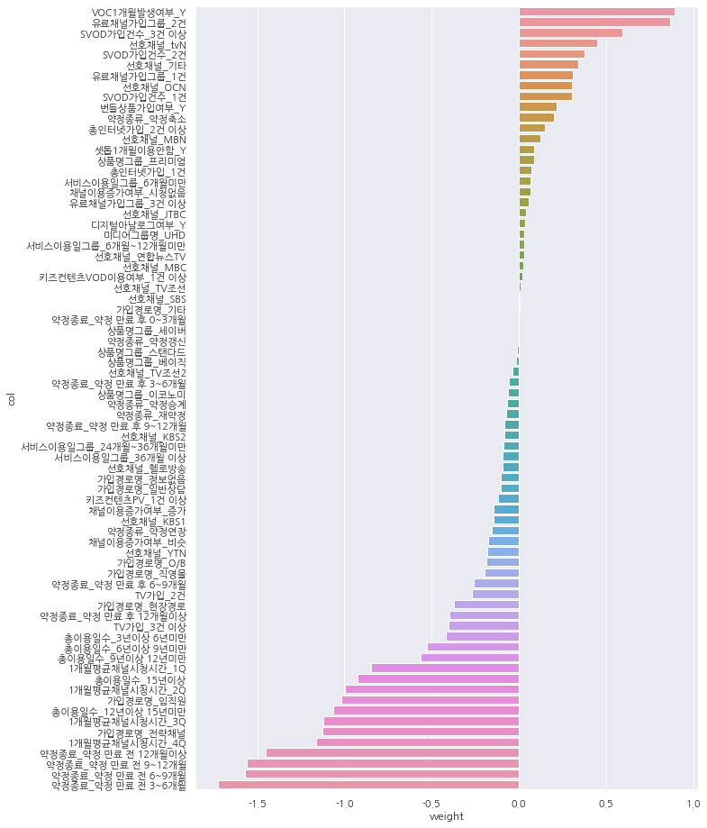

```python
logistic(X_train,y_train,X_test,y_test)
```

```python
def evaluation(X_train,y_train,X_test,y_test,model):
    global y_train_proba, y_train_pred,y_proba,y_pred

    # train data set
    y_train_proba= model.predict_proba(X_train)[:, 1]
    y_train_pred = model.predict(X_train)

    # test data set
    y_proba = model.predict_proba(X_test)[:, 1]
    y_pred = model.predict(X_test)

    print('________________________________________________________________________________________________________________________________________________________________')
    print('---------------------------------------------------------------Confusion Matrix---------------------------------------------------------------------------------')
    print('\n')

    # confusion matrix
    test_dt_con = confusion_matrix(y_test, y_pred)
    test_df_con = pd.DataFrame(test_dt_con, index = ['실제값(해지안함/F)', '실제값(해지/T)'], columns = ['예측값(해지안함/N)', '예측값(해지/P)'])
    sns.heatmap(test_df_con, annot = True, fmt = 'd', cmap = 'Blues', annot_kws = {'size' : 14})
    plt.show()

    global tn,fp,fn,tp

    tn, fp, fn, tp = confusion_matrix(y_test, y_pred).ravel()
    print('__________________________________________________________________________________________________________________________________________________________________')
    print('-------------------------------------------------------------------------ROC curve--------------------------------------------------------------------------------')
    print('\n')
    global fpr, tpr, thresholds, roc_auc_logit
    # roc_curve
    fpr, tpr, thresholds = roc_curve(y_test, y_proba)
    roc_auc_logit = auc(fpr,tpr)
    plt.figure(figsize=(7,7))
    plt.plot(fpr, tpr, label='ROC curve (area= %0.2f)' % roc_auc_logit)

    ##그래프에 직선 추가하기
    plt.plot([0,1],[0,1],color='navy', linestyle='--')

    #x축과 y축 구간 설정하기
    plt.xlim([0,1])
    plt.ylim([0,1.05])

    #축 이름 및 그래프 타이틀, 레전드 추가하기
    plt.xlabel('False Positive Rate')
    plt.ylabel('True Positive Rate')
    plt.title('Receiver Operating Characteristic Curve :Logistic')
    plt.legend(loc="lower right")

    plt.show()

    print(f'lr Model AUC: {auc(fpr, tpr)}')

    print('_________________________________________________________________________________________________________________________________________________________________________')
    print('----------------------------------------------------------------------------Classification Report------------------------------------------------------------------------')
    print('\n')

    print('Train Dataset 성능')
    print(classification_report(y_train,y_train_pred))
    print('_________________________________________________________________________________________________________________________________________________________________________')
    print('Test Dataset 성능')
    print(classification_report(y_test,y_pred))


    # imbalanced data 가중 평가지표 적용

    global ir, wei_acc, wei_pre, recall


    ir = y_test.value_counts()[0]/y_test.value_counts()[1] #testset의 불균형비율
    wei_acc = (tp*ir+tn)/((tp+fn)*ir+(fp+tn))
    wei_pre = tp*ir/(tp*ir+fp)
    recall = recall_score(y_test,y_pred)

    print('_________________________________________________________________________________________________________________________________________________________________')

    print('weighted_accuracy: ', wei_acc)
    print('weighted_precision: ', wei_pre)
    print('recall: ', recall)
```

```
________________________________________________________________________________________________________________________________________________________________
---------------------------------------------------------------Confusion Matrix---------------------------------------------------------------------------------
```

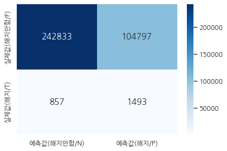

```
__________________________________________________________________________________________________________________________________________________________________
-------------------------------------------------------------------------ROC curve--------------------------------------------------------------------------------
```

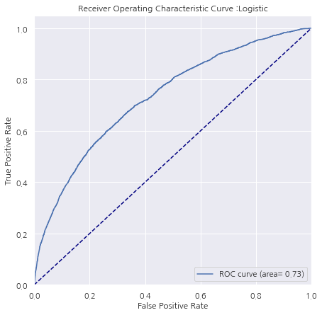

```
lr Model AUC: 0.7311112218236435
_________________________________________________________________________________________________________________________________________________________________________
----------------------------------------------------------------------------Classification Report------------------------------------------------------------------------


Train Dataset 성능
              precision    recall  f1-score   support

           0       0.66      0.71      0.68      7050
           1       0.68      0.63      0.66      7050

    accuracy                           0.67     14100
   macro avg       0.67      0.67      0.67     14100
weighted avg       0.67      0.67      0.67     14100

_________________________________________________________________________________________________________________________________________________________________________
Test Dataset 성능
              precision    recall  f1-score   support

           0       1.00      0.70      0.82    347630
           1       0.01      0.64      0.03      2350

    accuracy                           0.70    349980
   macro avg       0.51      0.67      0.42    349980
weighted avg       0.99      0.70      0.82    349980

_________________________________________________________________________________________________________________________________________________________________
weighted_accuracy:  0.666928912557433
weighted_precision:  0.6781942700684899
recall:  0.6353191489361703
```

```python
evaluation(X_train,y_train,X_test,y_test,logist)
```

```python
#logit에서 최적 threshold 찾기
roc_result = pd.DataFrame([fpr,tpr,thresholds], index=['fpr','tpr','thresholds']).T
roc_result['best'] = (1-roc_result['fpr'])+(roc_result['tpr']) # 1종오류,2종오류 최소화

roc_result
```

|  | fpr | tpr | thresholds | best |
| --- | --- | --- | --- | --- |
| 0 | 0.000000 | 0.000000 | 1.974447 | 1.000000 |
| 1 | 0.000003 | 0.000000 | 0.974447 | 0.999997 |
| 2 | 0.000032 | 0.000000 | 0.958586 | 0.999968 |
| 3 | 0.000032 | 0.000426 | 0.958577 | 1.000394 |
| 4 | 0.000037 | 0.000426 | 0.957927 | 1.000388 |
| ... | ... | ... | ... | ... |
| 71844 | 0.999632 | 1.000000 | 0.065473 | 1.000368 |
| 71845 | 0.999640 | 1.000000 | 0.065471 | 1.000360 |
| 71846 | 0.999882 | 1.000000 | 0.055132 | 1.000118 |
| 71847 | 0.999894 | 1.000000 | 0.054817 | 1.000106 |
| 71848 | 1.000000 | 1.000000 | 0.040208 | 1.000000 |

71849 rows × 4 columns

```
Best Threshold=0.040208, F-Score=1.000
```

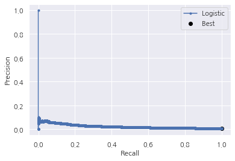

```python
from numpy import argmax
# calculate pr-curve
precision, recall, thres= precision_recall_curve(y_test, y_proba)

# convert to f score
# fscore = (2 * precision * recall) / (precision + recall)
# locate the index of the largest f score
ix = argmax(recall)
print('Best Threshold=%f, F-Score=%.3f' % (thres[ix], recall[ix]))
# plot the roc curve for the model
no_skill = len(y_test[y_test==1]) / len(y_test)

pyplot.plot(recall, precision, marker='.', label='Logistic')
pyplot.scatter(recall[ix], precision[ix], marker='o', color='black', label='Best')
# axis labels
pyplot.xlabel('Recall')
pyplot.ylabel('Precision')
pyplot.legend()
# show the plot
pyplot.show()
```

```python
# 1종오류, 2종오류를 최소화하는 최적의 threshold
optimal_threshold_logit=roc_result.thresholds[roc_result.best.idxmax()]
optimal_threshold_logit
```

```
0.5255562848643918
```

```python
y_pred= [1 if x >0.5241999784198018 else 0 for x in y_proba]
```

```python
tn,fp,fn,tp=confusion_matrix(y_test,y_pred).ravel()
tn,fp,fn,tp
```

```
(256517, 91113, 942, 1408)
```

```python
print(classification_report(y_test,y_pred)) # accuracy 소폭상승
```

```
              precision    recall  f1-score   support

           0       1.00      0.74      0.85    347630
           1       0.02      0.60      0.03      2350

    accuracy                           0.74    349980
   macro avg       0.51      0.67      0.44    349980
weighted avg       0.99      0.74      0.84    349980
```

# XGBoost

```python
from xgboost import XGBClassifier, plot_importance
from sklearn.model_selection import StratifiedKFold, cross_val_score
from sklearn.ensemble import RandomForestClassifier, VotingClassifier, StackingClassifier
from sklearn.feature_selection import RFE
```

```**Booster parameters(모델 파라미터)**

n_estimators[default=100] : 트리 모델의 갯수 라고 생각하면 된다.

early_stopping_rounds : 최대한 몇 개의 트리를 완성할 것인지 valid loss에 더이상 진전이 없다면 멈춘다. n_estimators가 높을 때 주로 사용하며 과적합을 방지해준다.

learning_rate[default=0.1] : 학습 단계별로 이전 결과를 얼마나 반영할지 설정한다. 일반적으로는 0.01 ~ 0.2 사이의 값을 쓰며 너무 작게 하면 시간이 더 오래 걸리게 된다.

min_child_weight[default=1] : child 에서 필요한 모든 관측치에 대한 가중치의 최소합 이 값보다 샘플 수가 작으면 leaf node가 된다. 너무 크게 설정하면 Under-fitting 될 수 있다.

max_depth[default=6] : 트리의 최대 깊이를 뜻하며 일반적으로 3~10의 값으로 한다.

gamma[default=0] : 트리에서 추가적으로 가지를 나눌지 말지 결정하는 최소 손실 감소 값 값을 크게 설정할 수록 과적합이 감소하는 효과가 있다.

subsample[default=1] : 각 트리마다 데이터 샘플링 비율 over-fitting방지 일반적으로 0.5 ~ 1을 사용

colsample_bytree[default=1] : 각 트리마다 feature 샘플링 비율 일반적으로 0.5 ~ 1을 사용한다.

reg_lambda [default=1] : L2 규제(Ridge)

reg_alpha [default=0] : L1 규제(Lasso)

scale_pos_weight[default = 1] : 데이터가 불균형 할때 사용 보통은 음성 데이터 수 / 양성 데이터 수 값으로 한다.

**Learning Task parameters**

objective[default=reg:linear]

binary:logistic : 이진분류를 위한 로지스틱 회귀, 클래스가 아닌 예측 확률 반환

multi:softmax : softmax를 사용한 다중 클래스 분류, 클래스 반환

multi:softprob : softmax를 사용, 클래스에 대한 예상 확률 반환

eval_metric[목적함수에 따라 default가 다름 회귀-rmse/ 분류-error]

rmse : Root Mean Square Error

mae : Mean Absolute error

logloss : Negative log-likelihood

error : Binary classification error rate(임계값 0.5)

merror : multiclass classification error rate

mlogloss : multiclass logloss

auc : area under curve

seed[default=0] 시드값 고정(나중에 재현 할때 같은 값을 출력하기 위해서 사용함)```

```python
seed=2357

xgbc = XGBClassifier(
seed=seed,
use_label_encoder=False,
eval_metirc='merror')

# fit model

xgbc.fit(X_train,y_train,early_stopping_rounds=30,eval_metric='auc',eval_set=[(X_val,y_val)])
```

[output not shown]

```
XGBClassifier(base_score=0.5, booster='gbtree', callbacks=None,
              colsample_bylevel=1, colsample_bynode=1, colsample_bytree=1,
              early_stopping_rounds=None, enable_categorical=False,
              eval_metirc='merror', eval_metric=None, gamma=0, gpu_id=-1,
              grow_policy='depthwise', importance_type=None,
              interaction_constraints='', learning_rate=0.300000012,
              max_bin=256, max_cat_to_onehot=4, max_delta_step=0, max_depth=6,
              max_leaves=0, min_child_weight=1, missing=nan,
              monotone_constraints='()', n_estimators=100, n_jobs=0,
              num_parallel_tree=1, predictor='auto', random_state=2357,
              reg_alpha=0, ...)
```

```
              precision    recall  f1-score   support

           0       1.00      0.70      0.82    347630
           1       0.01      0.63      0.03      2350

    accuracy                           0.70    349980
   macro avg       0.51      0.66      0.42    349980
weighted avg       0.99      0.70      0.81    349980
```

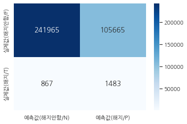

```python
y_pred = xgbc.predict(X_test)
y_prob = xgbc.predict_proba(X_test)[:,1]

# summarize results
print(classification_report(y_test,y_pred))

# confusion matrix
test_dt_con = confusion_matrix(y_test, y_pred)
test_df_con = pd.DataFrame(test_dt_con, index = ['실제값(해지안함/F)', '실제값(해지/T)'], columns = ['예측값(해지안함/N)', '예측값(해지/P)'])
sns.heatmap(test_df_con, annot = True, fmt = 'd', cmap = 'Blues', annot_kws = {'size' : 14})
plt.show()

tn, fp, fn, tp = confusion_matrix(y_test, y_pred).ravel()
```

```python
fpr,tpr,thredsholds = roc_curve(y_test, y_prob)
```

```python
auc_score = auc(fpr,tpr)
auc_score
```

```
0.7238981149559234
```

```python
y_pred_train = xgbc.predict(X_train)
y_prob_train = xgbc.predict_proba(X_train)[:,1]
```

```python
print(classification_report(y_train,y_pred_train))
```

```
              precision    recall  f1-score   support

           0       0.69      0.73      0.71      7050
           1       0.71      0.67      0.69      7050

    accuracy                           0.70     14100
   macro avg       0.70      0.70      0.70     14100
weighted avg       0.70      0.70      0.70     14100
```

```
________________________________________________________________________________________________________________________________________________________________
---------------------------------------------------------------Confusion Matrix---------------------------------------------------------------------------------
```

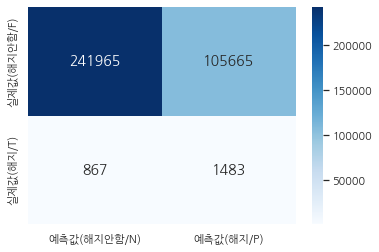

```
__________________________________________________________________________________________________________________________________________________________________
-------------------------------------------------------------------------ROC curve--------------------------------------------------------------------------------
```

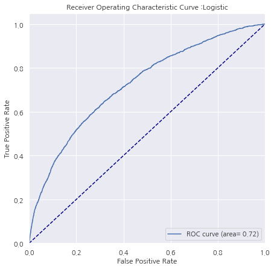

```
lr Model AUC: 0.7238981149559234
_________________________________________________________________________________________________________________________________________________________________________
----------------------------------------------------------------------------Classification Report------------------------------------------------------------------------


Train Dataset 성능
              precision    recall  f1-score   support

           0       0.69      0.73      0.71      7050
           1       0.71      0.67      0.69      7050

    accuracy                           0.70     14100
   macro avg       0.70      0.70      0.70     14100
weighted avg       0.70      0.70      0.70     14100

_________________________________________________________________________________________________________________________________________________________________________
Test Dataset 성능
              precision    recall  f1-score   support

           0       1.00      0.70      0.82    347630
           1       0.01      0.63      0.03      2350

    accuracy                           0.70    349980
   macro avg       0.51      0.66      0.42    349980
weighted avg       0.99      0.70      0.81    349980

_________________________________________________________________________________________________________________________________________________________________
weighted_accuracy:  0.6635527991671263
weighted_precision:  0.6749186526681406
recall:  0.6310638297872341
```

```python
evaluation(X_train,y_train,X_test,y_test,xgbc)
```

#### gridsearch

```python
from sklearn.model_selection import GridSearchCV

# define grid parameters

xgboost_params ={
    'learning_rate':[0.05,0.1,0.3],
    'max_depth' : [3,5,7,9],
    'min_child_weight' :[1,3,5,7,9],
    'colsample_bytree':[0.5,0.75],
    'max_delta_step':[3,5,7],
    'sampling_method' : ['uniform',
                        'gradient_based']
}
# define model again
xgbc = XGBClassifier(
seed=seed,
use_label_encoder=False)

# grid search
grid_search = GridSearchCV(
estimator=xgbc,
param_grid=xgboost_params,
n_jobs=-1, cv=3,
scoring='f1',
error_score=0)

grid_result=grid_search.fit(X_train,y_train,early_stopping_rounds=30,eval_set=[(X_val,y_val)])

# set best parameters
final_model = xgbc.set_params(
**grid_result.best_params)

#fit final model
final_model.fit(X_train,y_train)
```

```python
#predicitons for final model

y_pred_train = final_model.predict(X_train)
y_pred_prob_train = final_model.predict_proba(X_train)[:,1]


y_pred = final_model.predict(X_test)
y_prob = final_model.predict_proba(X_test)[:,1]
```

```python
# summarize results
print(classification_report(y_test,y_pred))

fpr,tpr,thredsholds = roc_curve(y_test, y_pred_prob)

precision, recall, threds = precision_recall_curve(y_test, y_pred_prob)


# confusion matrix
test_dt_con = confusion_matrix(y_test, y_pred_prob)
test_df_con = pd.DataFrame(test_dt_con, index = ['실제값(해지안함/F)', '실제값(해지/T)'], columns = ['예측값(해지안함/N)', '예측값(해지/P)'])
sns.heatmap(test_df_con, annot = True, fmt = 'd', cmap = 'Blues', annot_kws = {'size' : 14})
plt.show()

tn, fp, fn, tp = confusion_matrix(y_test, y_pred).ravel()


#logit에서 최적 threshold 찾기
roc_result = pd.DataFrame([fpr,tpr,thresholds], index=['fpr','tpr','thresholds']).T
roc_result['best'] = (1-roc_result['fpr'])+(roc_result['tpr']) # 1종오류,2종오류 최소화

roc_result


print(classification_report(y_test,y_pred)) # accuracy 소폭상승
```

[output not shown]

```python
# calculate pr-curve

from numpy import argmax
precision, recall, thres= precision_recall_curve(y_test, y_pred_prob)

# convert to f score
# fscore = (2 * precision * recall) / (precision + recall)
# locate the index of the largest f score
ix = argmax(fscore)
print('Best Threshold=%f, F-Score=%.3f' % (thres[ix], fscore[ix]))
# plot the roc curve for the model
no_skill = len(y_test[y_test==1]) / len(y_test)

pyplot.plot(recall, precision, marker='.', label='Logistic')
pyplot.scatter(recall[ix], precision[ix], marker='o', color='black', label='Best')
# axis labels
pyplot.xlabel('Recall')
pyplot.ylabel('Precision')
pyplot.legend()
# show the plot
pyplot.show()
```

[output not shown]

```python
# 1종오류, 2종오류를 최소화하는 최적의 threshold
optimal_threshold_xgb=roc_result.thresholds[roc_result.best.idxmax()]
optimal_threshold_xgb
```

[output not shown]

```python
y_pred_xgb = [1 if x >0.5271098412207599 else 0 for x in y_pred_prob]
```

```python
tn,fp,fn,tp=confusion_matrix(y_test,y_pred_xgb).ravel()
tn,fp,fn,tp
```

[output not shown]

```python
print(classification_report(y_test,y_pred_xgb)) # accuracy 소폭상승
```

[output not shown]

```python
from xgboost import plot_importance
import matplotlib.pyplot as plt
%matplotlib inline

fig, ax = plt.subplots(figsize=(10, 12))
plot_importance(xgb_model, ax=ax)
```

[output not shown]

# LASSO

```python
from sklearn.linear_model import LinearRegression, Ridge, Lasso
lasso_model = Lasso()
lasso_model.fit(X_train,y_train)
```

```python
thres_list = [0.05, 0.1, 0.15, 0.2, 0.25, 0.3, 0.35, 0.4, 0.45, 0.5, 0.55, 0.6, 0.65, 0.7, 0.75, 0.8, 0.85, 0.9, 0.95, 0.99]
df_thres = pd.DataFrame(index = threshold_list, columns = ['accuracy', 'recall'])

for thres in threshold_list :
    #print('=================== Threshold : ' + str(thres) + ' ===================')
    test_y_pred_prob = np.zeros(len(y_score_lr))


    for i in range(len(y_score_lr)):
        if  y_score_lr[i] > thres :
            test_y_pred_prob[i] = 1

    accuracy = (tp + tn) / (tp + fn + fp + tn)
    recall = tn / (fp + tn)

    df_thres.loc[thres, 'accuracy'] = accuracy
    df_thres.loc[thres, 'recall'] = recall
```

```python
# y_train_score_lr = lasso_model.predict_proba(X_train)[:, 1]
y_train_pred_lr = lasso_model.predict(X_train)

# test data set
# y_score_lr = lasso_model.predict_proba(X_test)[:, 1]
y_pred_lr = lasso_model.predict(X_test)

for thres in thres_list :
    # threshold 값 기준으로 y값 0 / 1로 분류
    Y = y_pred_lr.copy()
    Y[Y > thres] = 1
    Y[Y <= thres] = 0
    Y.astype(int)
    # Confusion matrix 생성 후 정확도 확인
    cfmat = confusion_matrix(y_test, Y)
```

```python
cfmat
```

[output not shown]

```python
ls_0005 = Lasso(alpha = 0.005)
ls_0005.fit(X_train, y_train)
# feature 확인
feature_selected = np.array(X_train.columns)
print(feature_selected[np.where(ls_0005.coef_ != 0)])
```

[output not shown]

```python
feature_selected
```

```python
print(classification_report(y_test,Y))
```

[output not shown]

```python
def evaluation(y_test,proba,pred,X_test,model):
    #score and prediction

    global y_score_lr, y_pred_lr, tn,fp,fn,tp
    y_score_lr = logist.predict_proba(X_test)[:, 1]
    y_pred_lr = logist.predict(X_test)
    tn, fp, fn, tp = confusion_matrix(y_test,y_score_lr).ravel()

    print('_________________________________________________________________________________________')
    print('----------------------------------ROC curve-----------------------------------------')
    print('\n')
    # roc_curve
    fpr, tpr, thresholds = roc_curve(y_test, y_score_lr)

    fig = px.area(
        x=fpr, y=tpr,
        title=f'<b>{model} model:</b> ROC Curve (AUC={auc(fpr, tpr):.4f})',
        labels=dict(x='False Positive Rate', y='True Positive Rate'),
        width=600, height=600
    )
    fig.add_shape(
        type='line', line=dict(dash='dash'),
        x0=0, x1=1, y0=0, y1=1
    )

    fig.update_yaxes(scaleanchor="x", scaleratio=1)
    fig.update_xaxes(constrain='domain')
    fig.show()

    print(f'lr Model AUC: {auc(fpr, tpr)}')

    print('________________________________________________________________________________________________________')
    print('----------------------------------Classification Report-----------------------------------------')
    print('\n')
    print(classification_report(y_test,y_pred_lr))


    # imbalanced data 가중 평가지표 적용
    global ir, wei_acc, wei_pre, recall
    ir = y_test.value_counts()[0]/y_test.value_counts()[1] #testset의 불균형비율
    wei_acc = (tp*ir+tn)/((tp+fn)*ir+(fp+tn))
    wei_pre = tp*ir/(tp*ir+fp)
    recall = recall_score(y_test,pred)
```